# ML ASS 2 CVD PREDICTION MODEL2

KIBIDI

2026-04-16

## R Markdown

Course: PROFFESIONAL CERTIFICATE IN DATA ANALYSIS, MACHINE LEARNING AND AI Instructor: Lumumba W. Victor Email: lumumbavictor172@gmail.com

student: KIBIDI LERENCER Reg no: CDAM/0047/2026 Email: kabeyi24leren@gmail.com

Date Issued: April , 2026

```r
setwd("C:/331199")
```

3 Tasks 3.1 Task 1: Data Import and Exploration (10 Marks)

#3.1.1. Load all necessary libraries

```r
library(tidyverse)# Data manipulation
library(caret)# Unified ML interface
library(pROC)# ROC analysis
library(e1071)# SVM
library(class)# KNN
library(randomForest) # Random Forest
library(dplyr)
```

#3.1.2. Import the dataset medical_data.csv.

```r
hypertension <- read_csv("medical_data.csv")
head(hypertension)
```

```
## # A tibble: 6 × 16
##     age gender   bmi blood_pressure cholesterol glucose smoking alcohol
##   <dbl>  <dbl> <dbl>          <dbl>       <dbl>   <dbl>   <dbl>   <dbl>
## 1  36.6      0  19.9           127.        207.   106.        1       0
## 2  41.5      1  32.1           126.        144.    76.9       1       1
## 3  68.4      1  30.4           105.        156.   102.        1       0
## 4  46.1      1  25.5           140.        257.   131.        0       0
## 5  46.9      0  26.9           108.        139.    58.7       0       0
## 6  70.7      0  29.4           135.        285.    78.2       0       0
## # ℹ 8 more variables: physical_activity <dbl>, family_history <dbl>,
## #   stress_level <dbl>, heart_rate <dbl>, sleep_hours <dbl>,
## #   medication_adherence <dbl>, urban_residence <dbl>, CVD <chr>
```

#3.1.3a) Display the structure of the data (str())

```r
(str(hypertension))
```

```
## spc_tbl_ [2,500 × 16] (S3: spec_tbl_df/tbl_df/tbl/data.frame)
##  $ age                 : num [1:2500] 36.6 41.5 68.4 46.1 46.9 ...
##  $ gender              : num [1:2500] 0 1 1 1 0 0 0 1 1 0 ...
##  $ bmi                 : num [1:2500] 19.9 32.1 30.4 25.5 26.9 ...
##  $ blood_pressure      : num [1:2500] 127 126 105 140 108 ...
##  $ cholesterol         : num [1:2500] 207 144 156 257 139 ...
##  $ glucose             : num [1:2500] 105.8 76.9 101.6 130.7 58.7 ...
##  $ smoking             : num [1:2500] 1 1 1 0 0 0 0 0 0 0 ...
##  $ alcohol             : num [1:2500] 0 1 0 0 0 0 1 0 1 0 ...
##  $ physical_activity   : num [1:2500] 1.66 1.55 3.9 3.49 1.58 ...
##  $ family_history      : num [1:2500] 0 0 0 1 0 0 1 1 0 0 ...
##  $ stress_level        : num [1:2500] 3.327 4.559 0.793 1.664 2.804 ...
##  $ heart_rate          : num [1:2500] 77.8 79.9 77.9 83.5 90.3 ...
##  $ sleep_hours         : num [1:2500] 5.81 5.3 7.87 7.78 7.31 ...
##  $ medication_adherence: num [1:2500] 1 0 1 1 0 1 0 1 1 1 ...
##  $ urban_residence     : num [1:2500] 1 1 1 0 0 1 0 1 1 1 ...
##  $ CVD                 : chr [1:2500] "No" "No" "No" "No" ...
##  - attr(*, "spec")=
##   .. cols(
##   ..   age = col_double(),
##   ..   gender = col_double(),
##   ..   bmi = col_double(),
##   ..   blood_pressure = col_double(),
##   ..   cholesterol = col_double(),
##   ..   glucose = col_double(),
##   ..   smoking = col_double(),
##   ..   alcohol = col_double(),
##   ..   physical_activity = col_double(),
##   ..   family_history = col_double(),
##   ..   stress_level = col_double(),
##   ..   heart_rate = col_double(),
##   ..   sleep_hours = col_double(),
##   ..   medication_adherence = col_double(),
##   ..   urban_residence = col_double(),
##   ..   CVD = col_character()
##   .. )
##  - attr(*, "problems")=<externalptr>
```

#3.1.3b) Display summary statistics (summary()).

```r
(summary(hypertension))
```

```
##       age              gender            bmi        blood_pressure
##  Min.   :-0.7179   Min.   :0.0000   Min.   :10.55   Min.   : 72.32
##  1st Qu.:35.2672   1st Qu.:0.0000   1st Qu.:23.70   1st Qu.:119.62
##  Median :44.9432   Median :0.0000   Median :27.08   Median :129.92
##  Mean   :45.1594   Mean   :0.4916   Mean   :26.99   Mean   :130.09
##  3rd Qu.:54.9905   3rd Qu.:1.0000   3rd Qu.:30.32   3rd Qu.:140.70
##  Max.   :95.8556   Max.   :1.0000   Max.   :45.58   Max.   :187.72
##   cholesterol        glucose           smoking          alcohol
##  Min.   : 63.92   Min.   :  2.665   Min.   :0.0000   Min.   :0.000
##  1st Qu.:173.84   1st Qu.: 79.766   1st Qu.:0.0000   1st Qu.:0.000
##  Median :199.01   Median : 99.732   Median :0.0000   Median :0.000
##  Mean   :199.80   Mean   : 99.649   Mean   :0.2904   Mean   :0.384
##  3rd Qu.:227.21   3rd Qu.:120.783   3rd Qu.:1.0000   3rd Qu.:1.000
##  Max.   :322.70   Max.   :187.584   Max.   :1.0000   Max.   :1.000
##  physical_activity family_history    stress_level      heart_rate
##  Min.   :-2.127    Min.   :0.0000   Min.   :-1.560   Min.   : 39.54
##  1st Qu.: 1.925    1st Qu.:0.0000   1st Qu.: 3.642   1st Qu.: 67.82
##  Median : 2.909    Median :0.0000   Median : 4.994   Median : 74.95
##  Mean   : 2.930    Mean   :0.2472   Mean   : 4.970   Mean   : 74.96
##  3rd Qu.: 3.905    3rd Qu.:0.0000   3rd Qu.: 6.297   3rd Qu.: 82.19
##  Max.   : 8.555    Max.   :1.0000   Max.   :12.843   Max.   :118.23
##   sleep_hours     medication_adherence urban_residence     CVD
##  Min.   : 2.544   Min.   :0.0000       Min.   :0.000   Length:2500
##  1st Qu.: 5.938   1st Qu.:0.0000       1st Qu.:0.000   Class :character
##  Median : 6.919   Median :1.0000       Median :1.000   Mode  :character
##  Mean   : 6.953   Mean   :0.6792       Mean   :0.596
##  3rd Qu.: 7.985   3rd Qu.:1.0000       3rd Qu.:1.000
##  Max.   :12.253   Max.   :1.0000       Max.   :1.000
```

#3.1.4a) Check for missing values per variable.

```r
colSums(is.na(hypertension))
```

```
##                  age               gender                  bmi
##                    0                    0                    0
##       blood_pressure          cholesterol              glucose
##                    0                    0                    0
##              smoking              alcohol    physical_activity
##                    0                    0                    0
##       family_history         stress_level           heart_rate
##                    0                    0                    0
##          sleep_hours medication_adherence      urban_residence
##                    0                    0                    0
##                  CVD
##                    0
```

#3.1.4b) report the count and percentage per variable.

```r
missing_summary <- data.frame(
  Variable = names(hypertension),
  Missing_Count = colSums(is.na(hypertension)),
  Missing_Percent = colMeans(is.na(hypertension)) * 100
)

missing_summary
```

```
##                                  Variable Missing_Count Missing_Percent
## age                                   age             0               0
## gender                             gender             0               0
## bmi                                   bmi             0               0
## blood_pressure             blood_pressure             0               0
## cholesterol                   cholesterol             0               0
## glucose                           glucose             0               0
## smoking                           smoking             0               0
## alcohol                           alcohol             0               0
## physical_activity       physical_activity             0               0
## family_history             family_history             0               0
## stress_level                 stress_level             0               0
## heart_rate                     heart_rate             0               0
## sleep_hours                   sleep_hours             0               0
## medication_adherence medication_adherence             0               0
## urban_residence           urban_residence             0               0
## CVD                                   CVD             0               0
```

#3.1.5. Visualize the distribution of the target variable CVD using a bar plot.

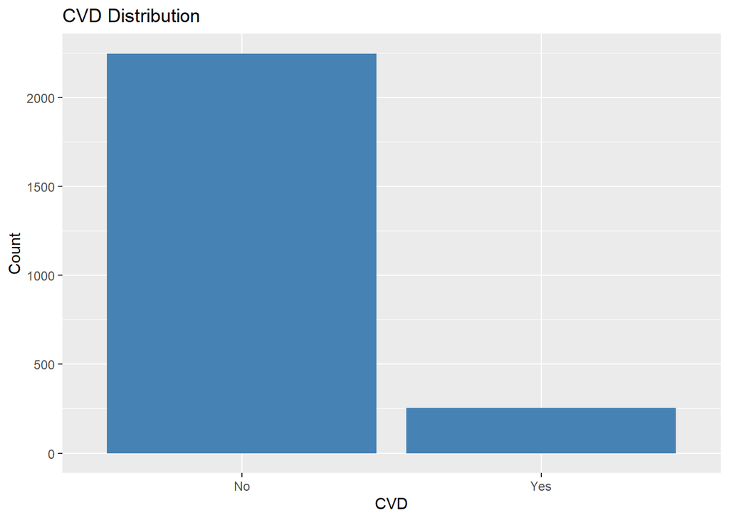

```r
 ggplot(hypertension, aes(x = factor(CVD))) +
geom_bar(fill = "steelblue") +
labs(title = "CVD Distribution", x = "CVD", y = "Count")
```

#3.1.6a) Calculate and report the class imbalance ratio

```r
class_counts <- table(hypertension$CVD)

IR <- max(class_counts) / min(class_counts)

IR
```

```
## [1] 8.881423
```

```r
#percentage
prop.table(class_counts) * 100
```

```
##
##    No   Yes
## 89.88 10.12
```

#3.1.6b)visualize class imbalance ratio in percentage

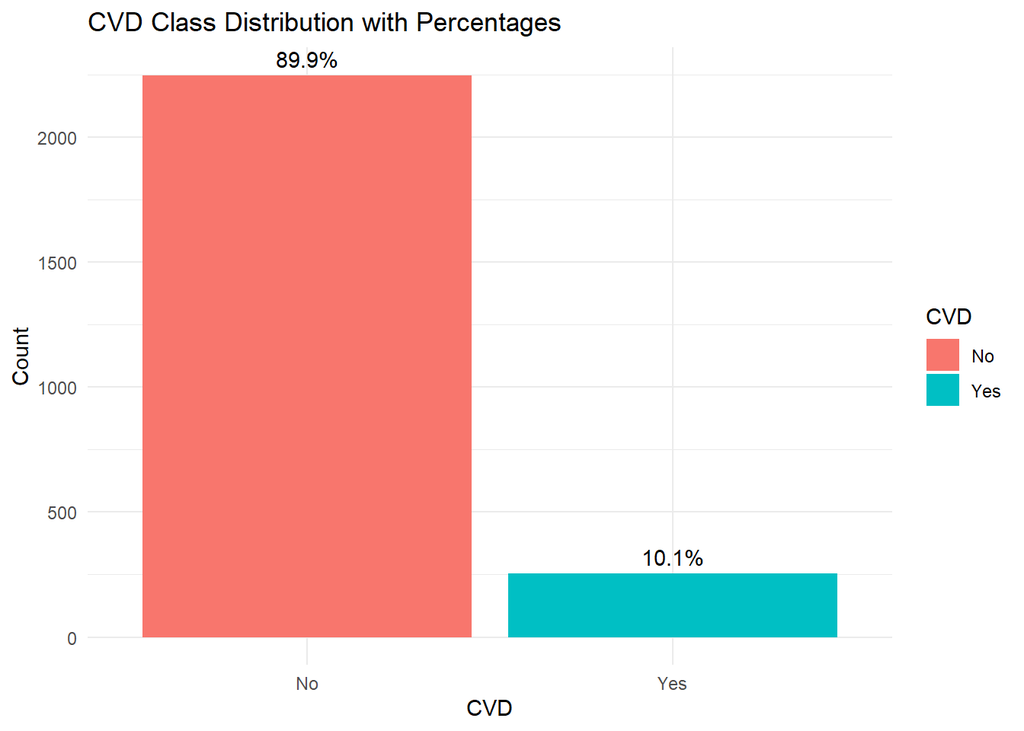

```r
hypertension %>%
  count(CVD) %>%
  mutate(Percent = n / sum(n) * 100) %>%
  ggplot(aes(x = CVD, y = n, fill = CVD)) +
  geom_bar(stat = "identity") +
  geom_text(aes(label = paste0(round(Percent,1), "%")),
            vjust = -0.5) +
  labs(title = "CVD Class Distribution with Percentages",
       x = "CVD",
       y = "Count") +
  theme_minimal()
```

3.2 Task 2: Data Preprocessing (15 Marks) #3.2.1. Handle missing values (justify your method: removal or imputation).

```r
hypertension_clean <- na.omit(hypertension)
```

Missing values were handled using removal because the dataset contained no significant missing data,this is to ensure data completeness without introducing bias from imputation.

#3.2.2. Convert categorical variables to factors:

```r
categorical_vars <- c("gender", "smoking", "alcohol",
                      "family_history", "medication_adherence", "urban_residence")

hypertension_clean[categorical_vars] <- lapply(hypertension_clean[categorical_vars], as.factor)
```

#3.2.3a) Convert the target variable CVD to a factor with levels “No” (0) and “Yes” (1).

```r
hypertension_clean$CVD <- factor(hypertension_clean$CVD,
                                 levels = c("No", "Yes"))
```

#3.2.3b)verify factors conversion

```r
str(hypertension_clean)
```

```
## tibble [2,500 × 16] (S3: tbl_df/tbl/data.frame)
##  $ age                 : num [1:2500] 36.6 41.5 68.4 46.1 46.9 ...
##  $ gender              : Factor w/ 2 levels "0","1": 1 2 2 2 1 1 1 2 2 1 ...
##  $ bmi                 : num [1:2500] 19.9 32.1 30.4 25.5 26.9 ...
##  $ blood_pressure      : num [1:2500] 127 126 105 140 108 ...
##  $ cholesterol         : num [1:2500] 207 144 156 257 139 ...
##  $ glucose             : num [1:2500] 105.8 76.9 101.6 130.7 58.7 ...
##  $ smoking             : Factor w/ 2 levels "0","1": 2 2 2 1 1 1 1 1 1 1 ...
##  $ alcohol             : Factor w/ 2 levels "0","1": 1 2 1 1 1 1 2 1 2 1 ...
##  $ physical_activity   : num [1:2500] 1.66 1.55 3.9 3.49 1.58 ...
##  $ family_history      : Factor w/ 2 levels "0","1": 1 1 1 2 1 1 2 2 1 1 ...
##  $ stress_level        : num [1:2500] 3.327 4.559 0.793 1.664 2.804 ...
##  $ heart_rate          : num [1:2500] 77.8 79.9 77.9 83.5 90.3 ...
##  $ sleep_hours         : num [1:2500] 5.81 5.3 7.87 7.78 7.31 ...
##  $ medication_adherence: Factor w/ 2 levels "0","1": 2 1 2 2 1 2 1 2 2 2 ...
##  $ urban_residence     : Factor w/ 2 levels "0","1": 2 2 2 1 1 2 1 2 2 2 ...
##  $ CVD                 : Factor w/ 2 levels "No","Yes": 1 1 1 1 1 1 2 1 1 1 ...
```

#3.2.4. For KNN and SVM:Scale numeric predictors(mean=0, sd=1)using preProcess()from caret. #3.2.4a) site numerical variables

```r
numeric_vars <- names(hypertension_clean)[sapply(hypertension_clean, is.numeric)]

numeric_vars
```

```
## [1] "age"               "bmi"               "blood_pressure"
## [4] "cholesterol"       "glucose"           "physical_activity"
## [7] "stress_level"      "heart_rate"        "sleep_hours"
```

#3.2.4b)Scale numeric predictors

```r
 numeric_vars <- c("age", "bmi", "blood_pressure", "cholesterol",
                  "glucose", "stress_level", "heart_rate", "sleep_hours")

preproc <- preProcess(hypertension_clean[, numeric_vars],
                      method = c("center", "scale"))

hypertension_scaled <- hypertension_clean

hypertension_scaled[, numeric_vars] <- predict(preproc,
                                               hypertension_clean[, numeric_vars])
```

#3.2.4c)verify scaling using numerical variable ‘age’

```r
cat("\n========== SCALING VERIFICATION ==========\n")
```

```
##
## ========== SCALING VERIFICATION ==========
```

```r
cat("Original age - Mean:", mean(hypertension_clean$age), "| SD:", sd(hypertension_clean$age), "\n")
```

```
## Original age - Mean: 45.15943 | SD: 14.83276
```

```r
cat("Scaled age - Mean:", round(mean(hypertension_scaled$age), 2), "| SD:", round(sd(hypertension_scaled$age), 2), "\n")
```

```
## Scaled age - Mean: 0 | SD: 1
```

#3.2.5. For Random Forest: Scaling is not required (tree-based). Scaling is not required for Random Forest because it is a tree-based algorithm that splits data using thresholds rather than distance or magnitude. Therefore, changes in scale do not affect model performance or splits.

3.3 Task 3: Data Partitioning (10 Marks)

#3.3.1. Set the seed to 2026 for reproducibility.

```r
 set.seed(2026)
```

#3.3.2. Split the data into 70% training and 30% testing using stratified sampling (to preserve class balance).

```r
 train_index <- createDataPartition(hypertension_clean$CVD, p = 0.70,
list = FALSE)
train_data <- hypertension_clean[train_index, ]
test_data <- hypertension_clean[-train_index, ]

dim(train_data)
```

```
## [1] 1751   16
```

```r
dim(test_data)
```

```
## [1] 749  16
```

#3.3.3. Report the class distribution (counts and percentages) in both training and testing sets.

```r
cat("Training Set:\n")
```

```
## Training Set:
```

```r
train_tab <- table(train_data$CVD)
print(train_tab)
```

```
##
##   No  Yes
## 1573  178
```

```r
cat("Percentages (%):\n")
```

```
## Percentages (%):
```

```r
print(round(prop.table(train_tab) * 100, 2))
```

```
##
##    No   Yes
## 89.83 10.17
```

```r
cat("\n========================\n")
cat("Testing Set:\n")
```

```
## Testing Set:
```

```r
test_tab <- table(test_data$CVD)
print(test_tab)
```

```
##
##  No Yes
## 674  75
```

```r
cat("Percentages (%):\n")
```

```
## Percentages (%):
```

```r
print(round(prop.table(test_tab) * 100, 2))
```

```
##
##    No   Yes
## 89.99 10.01
```

3.4 Task 4: TrainControl Scheme (10 Marks)

#3.4.1. Define a trainControl scheme with the following specifications:

```r
ctrl <- trainControl(
method = "cv",              # 10-fold cross-validation
number = 10,                # 10 folds
savePredictions = "final",  # Save predictions
classProbs = TRUE,          # Enable probability predictions
verboseIter = FALSE,        # ROC, Sens, Spec

summaryFunction = twoClassSummary, # Suppress iteration output
)
```

#3.4.3. Save this control object to use across all models.

3.5 Task 5: Model Training- Logistic Regression (15 Marks)

#3.5.1. Train a Logistic Regression model using caret::train() with method “glm”.

```r
log_model <- train(

CVD ~ age + gender + bmi + blood_pressure + cholesterol +
      glucose + smoking + alcohol + physical_activity +
      family_history + stress_level + sleep_hours,

data = train_data,
method = "glm",
family = binomial,
trControl = ctrl
)
```

#3.5.3. Extract and report the model coefficients.

```r
summary(log_model$finalModel)$coefficients
```

```
##                       Estimate  Std. Error   z value     Pr(>|z|)
## (Intercept)       -12.87410872 1.423237688 -9.045649 1.487786e-19
## age                 0.03939153 0.006614654  5.955192 2.597664e-09
## gender1             0.40431260 0.189778865  2.130441 3.313526e-02
## bmi                 0.08903708 0.018952247  4.697970 2.627602e-06
## blood_pressure      0.02190858 0.006266284  3.496264 4.718216e-04
## cholesterol         0.01523177 0.002534782  6.009102 1.865541e-09
## glucose             0.02457709 0.003354063  7.327558 2.343843e-13
## smoking1            0.83592575 0.197126042  4.240565 2.229581e-05
## alcohol1            0.22781366 0.190938119  1.193128 2.328192e-01
## physical_activity  -0.54704225 0.071870073 -7.611544 2.708398e-14
## family_history1     1.03448516 0.198332043  5.215925 1.829017e-07
## stress_level        0.32728663 0.049431245  6.621048 3.566620e-11
## sleep_hours        -0.54452329 0.071169403 -7.651087 1.992875e-14
```

#3.5.4a) Calculate Odds Ratios (OR) for at least 3 significant predictors: OR = eβ

```r
coefficients <- coef(log_model$finalModel)
odds_ratios <- exp(coefficients)
print(round(odds_ratios, 3))
```

```
##       (Intercept)               age           gender1               bmi
##             0.000             1.040             1.498             1.093
##    blood_pressure       cholesterol           glucose          smoking1
##             1.022             1.015             1.025             2.307
##          alcohol1 physical_activity   family_history1      stress_level
##             1.256             0.579             2.814             1.387
##       sleep_hours
##             0.580
```

#3.5.4b)odds table

```r
odds_table <- data.frame(
  Variable = names(odds_ratios),
  Coefficient = round(coefficients, 4),
  Odds_Ratio = round(odds_ratios, 3)
)

odds_table <- odds_table[order(-abs(odds_table$Coefficient)), ]

odds_table
```

```
##                            Variable Coefficient Odds_Ratio
## (Intercept)             (Intercept)    -12.8741      0.000
## family_history1     family_history1      1.0345      2.814
## smoking1                   smoking1      0.8359      2.307
## physical_activity physical_activity     -0.5470      0.579
## sleep_hours             sleep_hours     -0.5445      0.580
## gender1                     gender1      0.4043      1.498
## stress_level           stress_level      0.3273      1.387
## alcohol1                   alcohol1      0.2278      1.256
## bmi                             bmi      0.0890      1.093
## age                             age      0.0394      1.040
## glucose                     glucose      0.0246      1.025
## blood_pressure       blood_pressure      0.0219      1.022
## cholesterol             cholesterol      0.0152      1.015
```

#3.5.2a) Alternatively, fit a baseline model using base R glm() function.

```r
log_modelb <- glm(
  CVD ~ age + gender + bmi + blood_pressure + cholesterol +
      glucose + smoking + alcohol + physical_activity +
      family_history + stress_level + sleep_hours,

  data = train_data,
  family = binomial
)

summary(log_modelb)
```

```
##
## Call:
## glm(formula = CVD ~ age + gender + bmi + blood_pressure + cholesterol +
##     glucose + smoking + alcohol + physical_activity + family_history +
##     stress_level + sleep_hours, family = binomial, data = train_data)
##
## Coefficients:
##                     Estimate Std. Error z value Pr(>|z|)
## (Intercept)       -12.874109   1.423238  -9.046  < 2e-16 ***
## age                 0.039392   0.006615   5.955 2.60e-09 ***
## gender1             0.404313   0.189779   2.130 0.033135 *
## bmi                 0.089037   0.018952   4.698 2.63e-06 ***
## blood_pressure      0.021909   0.006266   3.496 0.000472 ***
## cholesterol         0.015232   0.002535   6.009 1.87e-09 ***
## glucose             0.024577   0.003354   7.328 2.34e-13 ***
## smoking1            0.835926   0.197126   4.241 2.23e-05 ***
## alcohol1            0.227814   0.190938   1.193 0.232819
## physical_activity  -0.547042   0.071870  -7.612 2.71e-14 ***
## family_history1     1.034485   0.198332   5.216 1.83e-07 ***
## stress_level        0.327287   0.049431   6.621 3.57e-11 ***
## sleep_hours        -0.544523   0.071169  -7.651 1.99e-14 ***
## ---
## Signif. codes:  0 '***' 0.001 '**' 0.01 '*' 0.05 '.' 0.1 ' ' 1
##
## (Dispersion parameter for binomial family taken to be 1)
##
##     Null deviance: 1151.13  on 1750  degrees of freedom
## Residual deviance:  783.56  on 1738  degrees of freedom
## AIC: 809.56
##
## Number of Fisher Scoring iterations: 6
```

#3.5.2b) Calculate Odds Ratios (OR) for at least 3 significant predictors: OR = eβ

```r
# Extract coefficients
coef_vals <- coef(log_modelb)

# Convert to odds ratios
odds_ratios <- exp(coef_vals)

# Get p-values from model summary
p_values <- summary(log_modelb)$coefficients[, 4]

# Create clean table
odds_table <- data.frame(
  Variable = names(coef_vals),
  Coefficient = round(coef_vals, 4),
  Odds_Ratio = round(odds_ratios, 3),
  P_value = round(p_values, 4)
)

# Remove row names
rownames(odds_table) <- NULL

# Sort by importance
odds_table <- odds_table[order(-abs(odds_table$Coefficient)), ]

odds_table
```

```
##             Variable Coefficient Odds_Ratio P_value
## 1        (Intercept)    -12.8741      0.000  0.0000
## 11   family_history1      1.0345      2.814  0.0000
## 8           smoking1      0.8359      2.307  0.0000
## 10 physical_activity     -0.5470      0.579  0.0000
## 13       sleep_hours     -0.5445      0.580  0.0000
## 3            gender1      0.4043      1.498  0.0331
## 12      stress_level      0.3273      1.387  0.0000
## 9           alcohol1      0.2278      1.256  0.2328
## 4                bmi      0.0890      1.093  0.0000
## 2                age      0.0394      1.040  0.0000
## 7            glucose      0.0246      1.025  0.0000
## 5     blood_pressure      0.0219      1.022  0.0005
## 6        cholesterol      0.0152      1.015  0.0000
```

3.6 Task 6: Model Training- KNN (15 Marks)

#3.6.1. Train a K-Nearest Neighbors model using caret::train() with method “knn”. #3.6.1a)create train scaled

```r
set.seed(2026)

train_scaled <- hypertension_scaled[train_index, ]
test_scaled <- hypertension_scaled[-train_index, ]

dim(train_scaled)
```

```
## [1] 1751   16
```

```r
dim(test_scaled)
```

```
## [1] 749  16
```

#3.6.2. Tune the parameter k (number of neighbors) using the grid: k = 1, 3, 5, …,21.

```r
knn_grid <- data.frame(k = seq(1, 21, by = 2))

ctrl <- trainControl(
  method = "cv",
  number = 10,
  classProbs = TRUE,
  summaryFunction = twoClassSummary
)

set.seed(2026)

knn_model <- train(
  CVD ~ age + gender + bmi + blood_pressure + cholesterol +
      glucose + smoking + alcohol + physical_activity +
      family_history + stress_level + sleep_hours,

  data = hypertension_scaled,
  method = "knn",
  tuneGrid = knn_grid,
  trControl = ctrl,
  metric = "ROC"
)

knn_model$results
```

```
##     k       ROC      Sens       Spec      ROCSD      SensSD     SpecSD
## 1   1 0.5848699 0.9243552 0.24538462 0.04198572 0.017106533 0.07869832
## 2   3 0.6663432 0.9755278 0.11876923 0.05237692 0.009202097 0.06236117
## 3   5 0.7155188 0.9866468 0.11492308 0.05227384 0.010490686 0.06853036
## 4   7 0.7323763 0.9888750 0.09076923 0.04377448 0.009200389 0.05632628
## 5   9 0.7503981 0.9910992 0.09092308 0.05206322 0.006294790 0.04226618
## 6  11 0.7585751 0.9946567 0.07123077 0.04643443 0.005059364 0.02533198
## 7  13 0.7722438 0.9951012 0.05938462 0.04487953 0.005334809 0.03361381
## 8  15 0.7742056 0.9968810 0.04338462 0.04412813 0.004723221 0.03917492
## 9  17 0.7782673 0.9982183 0.04338462 0.05151084 0.003117680 0.03433830
## 10 19 0.7867298 0.9982183 0.03538462 0.04982825 0.003117680 0.03417863
## 11 21 0.7861735 0.9986647 0.02353846 0.04528275 0.002150072 0.03309222
```

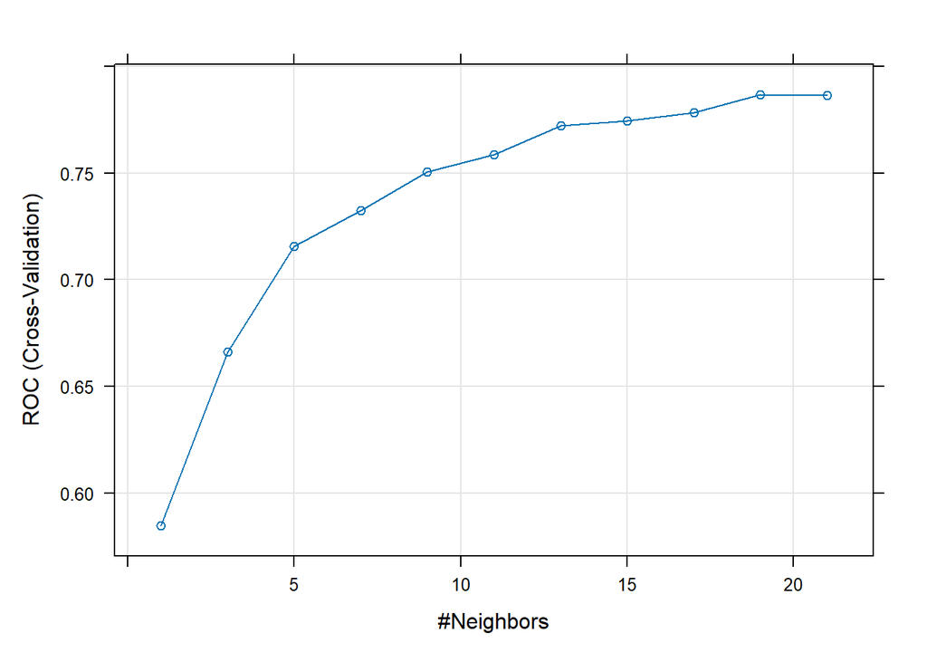

```r
plot(knn_model)
```

#3.6.3. Important: Use the scaled dataset for KNN (distance-based algorithm).

#3.6.4. Report the optimal k value selected by cross-validation.

```r
knn_model$bestTune
```

```
##     k
## 10 19
```

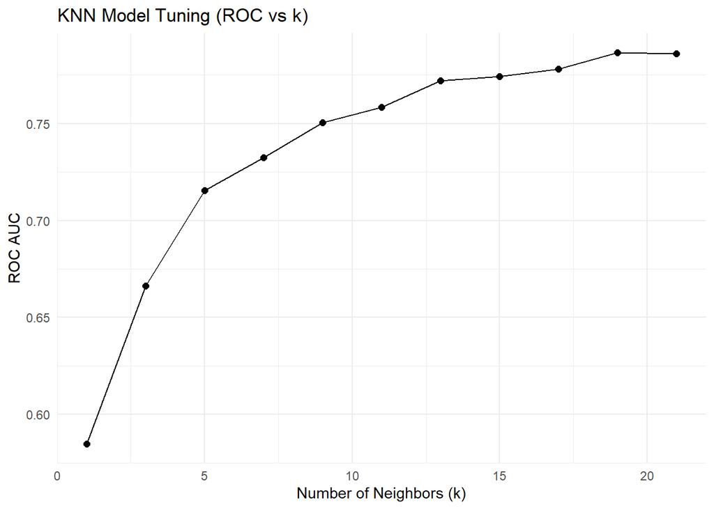

```r
ggplot(knn_model$results, aes(x = k, y = ROC)) +
  geom_line() +
  geom_point(size = 2) +
  labs(title = "KNN Model Tuning (ROC vs k)",
       x = "Number of Neighbors (k)",
       y = "ROC AUC") +
  theme_minimal()
```

3.7 Task 7: Model Training- SVM (15 Marks)

#3.7.1. Train a Support Vector Machine model using caret::train() with method “svmRadial”. #3.7.2. Tune the hyperparameters:C (cost): 0.25, 0.5, 1, 2, 4, sigma: 0.01, 0.05, 0.1, 0.5 #3.7.3. Important: Use the scaled dataset for SVM.

```r
set.seed(2026)

train_scaled <- hypertension_scaled[train_index, ]
test_scaled <- hypertension_scaled[-train_index, ]

dim(train_scaled)
```

```
## [1] 1751   16
```

```r
dim(test_scaled)
```

```
## [1] 749  16
```

```r
svm_model <- train(
  CVD ~ age + gender + bmi + blood_pressure + cholesterol +
      glucose + smoking + alcohol + physical_activity +
      family_history + stress_level + sleep_hours,

data = train_scaled, # Use scaled data!
method = "svmRadial",
trControl = ctrl,
tuneGrid = expand.grid(
C = c(0.25, 0.5, 1, 2, 4),
sigma = c(0.01, 0.05, 0.1, 0.5)
))
```

#3.7.4. Report the optimal C and sigma values.

```r
 svm_model$bestTune
```

```
##   sigma   C
## 5  0.01 0.5
```

3.8 Task 8: Model Training- Random Forest (15 Marks)

#3.8.1. Train a Random Forest model using caret::train() with method “rf”. #3.8.2. Tune the parameter mtry (features per split): 2, 4, 6, 8. #3.8.3. Set ntree = 500 (number of trees).

```r
 rf_model <- train(
   CVD ~ age + gender + bmi + blood_pressure + cholesterol +
      glucose + smoking + alcohol + physical_activity +
      family_history + stress_level + sleep_hours,

  data = train_data, # Original data (not scaled )
method = "rf",
trControl = ctrl,
tuneGrid = expand.grid(mtry = c(2, 4, 6, 8)),
ntree = 500
)
```

#3.8.4. Report the optimal mtry value.

```r
 rf_model$bestTune
```

```
##   mtry
## 2    4
```

#3.8.5. Extract and plot variable importance.

```r
varImp(rf_model)
```

```
## rf variable importance
##
##                    Overall
## physical_activity 100.0000
## sleep_hours        94.3954
## glucose            87.0905
## stress_level       83.8276
## age                83.3491
## cholesterol        79.3850
## bmi                69.5614
## blood_pressure     55.5402
## family_history1    13.8793
## smoking1            4.3718
## gender1             0.9689
## alcohol1            0.0000
```

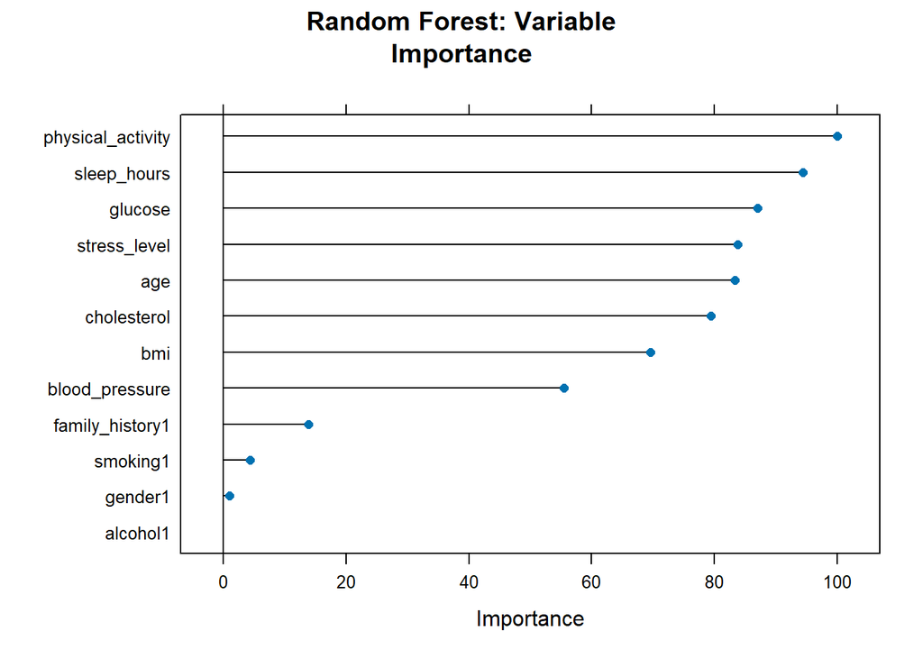

```r
plot(varImp(rf_model), main = "Random Forest: Variable
Importance")
```

#3.8.6. Identify the top 5 most important predictors for CVD.

```r
rf_imp <- varImp(rf_model)
rf_imp
```

```
## rf variable importance
##
##                    Overall
## physical_activity 100.0000
## sleep_hours        94.3954
## glucose            87.0905
## stress_level       83.8276
## age                83.3491
## cholesterol        79.3850
## bmi                69.5614
## blood_pressure     55.5402
## family_history1    13.8793
## smoking1            4.3718
## gender1             0.9689
## alcohol1            0.0000
```

```r
rf_imp_df <- rf_imp$importance
rf_imp_df$Variable <- rownames(rf_imp_df)

top5 <- rf_imp_df[order(-rf_imp_df$Overall), ][1:5, ]
top5
```

```
##                     Overall          Variable
## physical_activity 100.00000 physical_activity
## sleep_hours        94.39538       sleep_hours
## glucose            87.09047           glucose
## stress_level       83.82762      stress_level
## age                83.34909               age
```

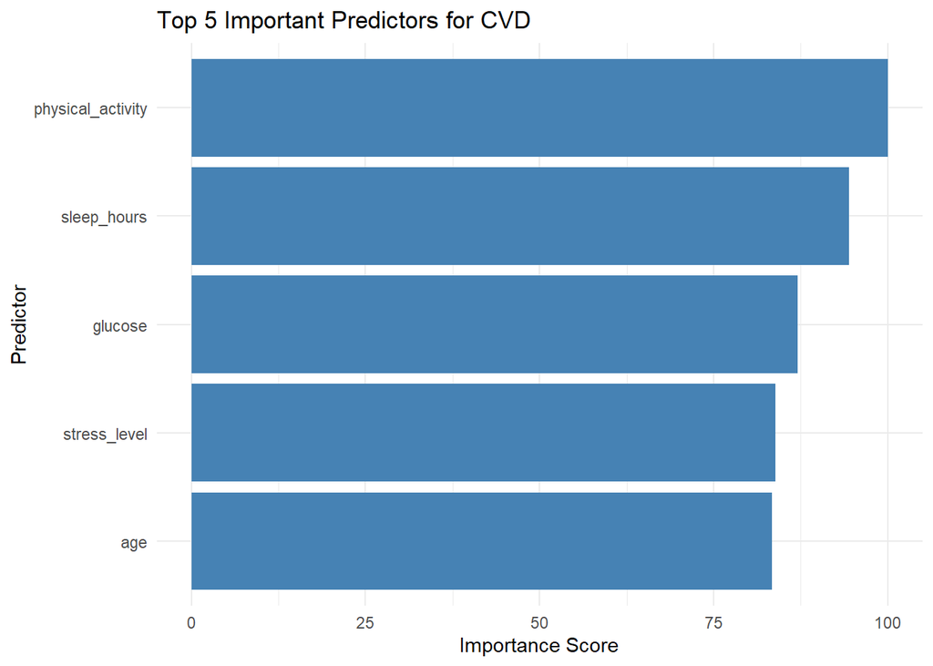

```r
ggplot(top5, aes(x = reorder(Variable, Overall), y = Overall)) +
  geom_bar(stat = "identity", fill = "steelblue") +
  coord_flip() +
  labs(title = "Top 5 Important Predictors for CVD",
       x = "Predictor",
       y = "Importance Score") +
  theme_minimal()
```

3.9 Task 9: Model Evaluation and Comparison (20 Marks)

#3.9.1. Predict the class and probabilities on the test set for all 4 models.

```r
log_pred <- predict(log_model, test_data)
log_probs <- predict(log_model, test_data, type = "prob")

knn_pred <- predict(knn_model, test_scaled)
knn_probs <- predict(knn_model, test_scaled, type = "prob")

svm_pred <- predict(svm_model, test_scaled)
svm_probs <- predict(svm_model, test_scaled, type = "prob")

rf_pred <- predict(rf_model, test_data)
rf_probs <- predict(rf_model, test_data, type = "prob")
```

#3.9.2. For each model, generate a Confusion Matrix and report: •Accuracy,•Sensitivity (Recall),•Specificity,•Precision (PPV),•F1-Score,•Kappa

```r
confusionMatrix(log_pred, test_data$CVD, positive = "Yes")
```

```
## Confusion Matrix and Statistics
##
##           Reference
## Prediction  No Yes
##        No  659  60
##        Yes  15  15
##
##                Accuracy : 0.8999
##                  95% CI : (0.8761, 0.9204)
##     No Information Rate : 0.8999
##     P-Value [Acc > NIR] : 0.5307
##
##                   Kappa : 0.2424
##
##  Mcnemar's Test P-Value : 3.761e-07
##
##             Sensitivity : 0.20000
##             Specificity : 0.97774
##          Pos Pred Value : 0.50000
##          Neg Pred Value : 0.91655
##              Prevalence : 0.10013
##          Detection Rate : 0.02003
##    Detection Prevalence : 0.04005
##       Balanced Accuracy : 0.58887
##
##        'Positive' Class : Yes
##
```

```r
confusionMatrix(knn_pred, test_scaled$CVD, positive = "Yes")
```

```
## Confusion Matrix and Statistics
##
##           Reference
## Prediction  No Yes
##        No  672  72
##        Yes   2   3
##
##                Accuracy : 0.9012
##                  95% CI : (0.8776, 0.9216)
##     No Information Rate : 0.8999
##     P-Value [Acc > NIR] : 0.4822
##
##                   Kappa : 0.0633
##
##  Mcnemar's Test P-Value : 1.048e-15
##
##             Sensitivity : 0.040000
##             Specificity : 0.997033
##          Pos Pred Value : 0.600000
##          Neg Pred Value : 0.903226
##              Prevalence : 0.100134
##          Detection Rate : 0.004005
##    Detection Prevalence : 0.006676
##       Balanced Accuracy : 0.518516
##
##        'Positive' Class : Yes
##
```

```r
confusionMatrix(svm_pred, test_scaled$CVD, positive = "Yes")
```

```
## Confusion Matrix and Statistics
##
##           Reference
## Prediction  No Yes
##        No  670  67
##        Yes   4   8
##
##                Accuracy : 0.9052
##                  95% CI : (0.8819, 0.9252)
##     No Information Rate : 0.8999
##     P-Value [Acc > NIR] : 0.3399
##
##                   Kappa : 0.1607
##
##  Mcnemar's Test P-Value : 1.866e-13
##
##             Sensitivity : 0.10667
##             Specificity : 0.99407
##          Pos Pred Value : 0.66667
##          Neg Pred Value : 0.90909
##              Prevalence : 0.10013
##          Detection Rate : 0.01068
##    Detection Prevalence : 0.01602
##       Balanced Accuracy : 0.55037
##
##        'Positive' Class : Yes
##
```